# Séries temporelles et reproductibilité

Mathieu Rémy

16/04/2020

# 1. Créer une série temporelle du CO2 à partir des données de hawai.csv

```r
## Lecture du fichier hawaï.csv
library('tidyverse')
library(lubridate) ## Package pour la manipulation des dates (notes de cours 11.1)
```

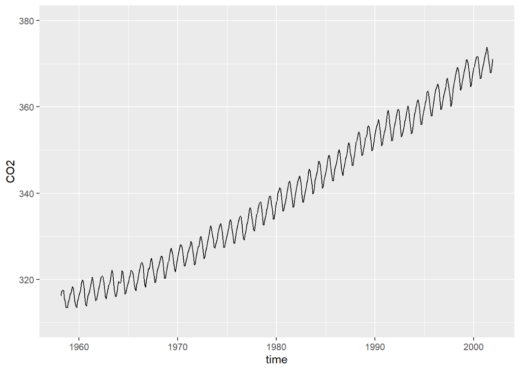

```r
Hawai <- read.csv('Hawai.csv', header = TRUE, sep = ',')

# Visualisation des données

 min_CO2 <-min(Hawai$CO2)
 max_CO2 <- max(Hawai$CO2) ## pour mieux ajuster le ylim

visua_1 <- ggplot(Hawai, aes(x = time , y = CO2 )) +
  ylim(310, 380)+
  geom_line()
visua_1 # voir le graph des données
```

```r
# Création de la série temporelle  (notes de cours 11.2)
library(forecast)
```

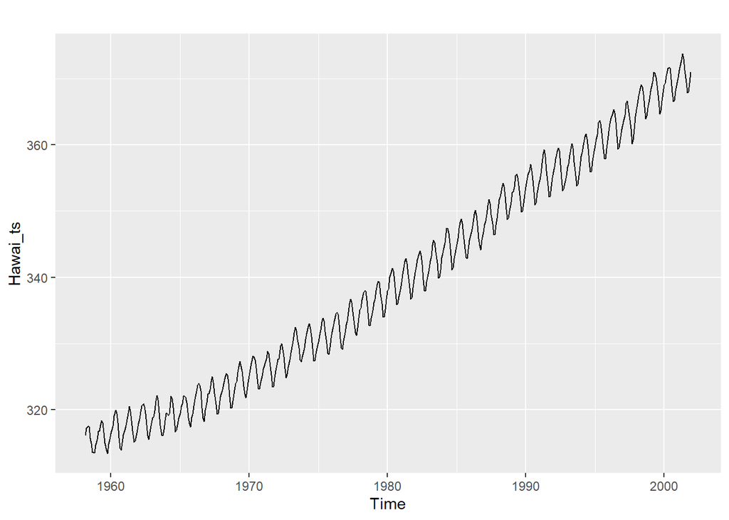

```r
Hawai_ts <- ts(Hawai$CO2,
                  start = c(Hawai$time[1]), # départ de la série à la première valeur
               frequency = 12)  ## Nombre de mois

autoplot(Hawai_ts) # visualisation graphique
```

# 2. Séparer la série en parties d’entraînement (environ 70% des données) et en partie test (notes de cour 11.3.1)

Nous voulons un modèle capable de prédire le futur. Pour cette raison, le jeu de données d’entraînement se fait sur les données (70%) du début de la série. Les restantes (30% des données) seront utilisées pour tester le modèle.

```r
bound <- floor((nrow(Hawai)*0.70))    # Trouver les données d'entrainement
bound
```

```
## [1] 368
```

```r
Hawai_ts_train <- window(Hawai_ts, start = 1958.167, end = 1988.833)
Hawai_ts_test <- window(Hawai_ts, start =   1988.917) # Basé sur l'exemple dans les notes de cours (11.3.1)
```

# 3. Créer un modèle ETS sur les données d’entraînement, puis projeter la prévision de CO2 atmosphérique pour comparer aux données test

```r
# Modèle ETS optimiser par R
# Basé sur l'exemple dans les notes de cours (11.3.2.4)

fit <- ets(Hawai_ts_train) # création du modèle
summary(fit) # sommaire des caractéristique du modèle créé
```

```
## ETS(M,Ad,M)
##
## Call:
##  ets(y = Hawai_ts_train)
##
##   Smoothing parameters:
##     alpha = 0.7538
##     beta  = 0.0348
##     gamma = 2e-04
##     phi   = 0.9761
##
##   Initial states:
##     l = 314.6724
##     b = 0.025
##     s = 1.004 1.0018 1 0.9973 0.994 0.9907
##            0.9912 0.9963 1.0022 1.0068 1.0086 1.0072
##
##   sigma:  0.001
##
##      AIC     AICc      BIC
## 1398.208 1400.173 1468.504
##
## Training set error measures:
##                      ME      RMSE      MAE        MPE       MAPE      MASE
## Training set 0.05221402 0.3310028 0.247852 0.01557531 0.07533287 0.2026326
##                     ACF1
## Training set -0.06517604
```

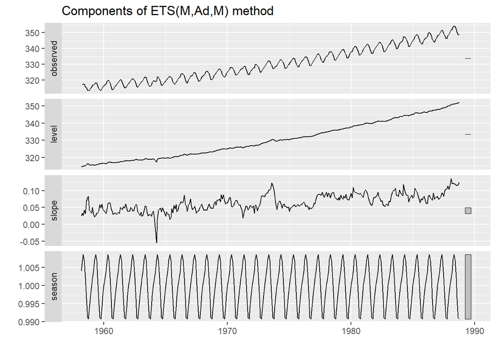

```r
autoplot(fit) # voir les données en graphique
```

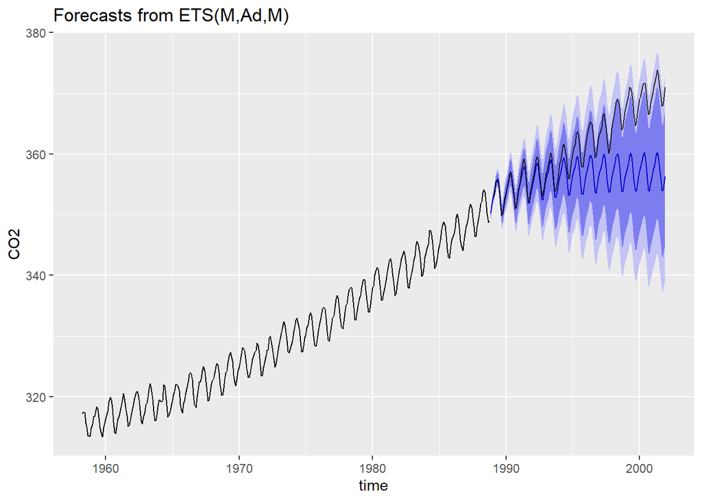

```r
pred_Hawai <- fit%>%
  forecast(h=158)  #Prédiction des données

autoplot(pred_Hawai) +    # Courbe des prédictions
  autolayer(Hawai_ts_test, color = rgb(0, 0, 0, 0.8)) +  # Courbe des données test
  labs(x = "time", y = "CO2")
```

# 4. Effectuer une analyse des résidus

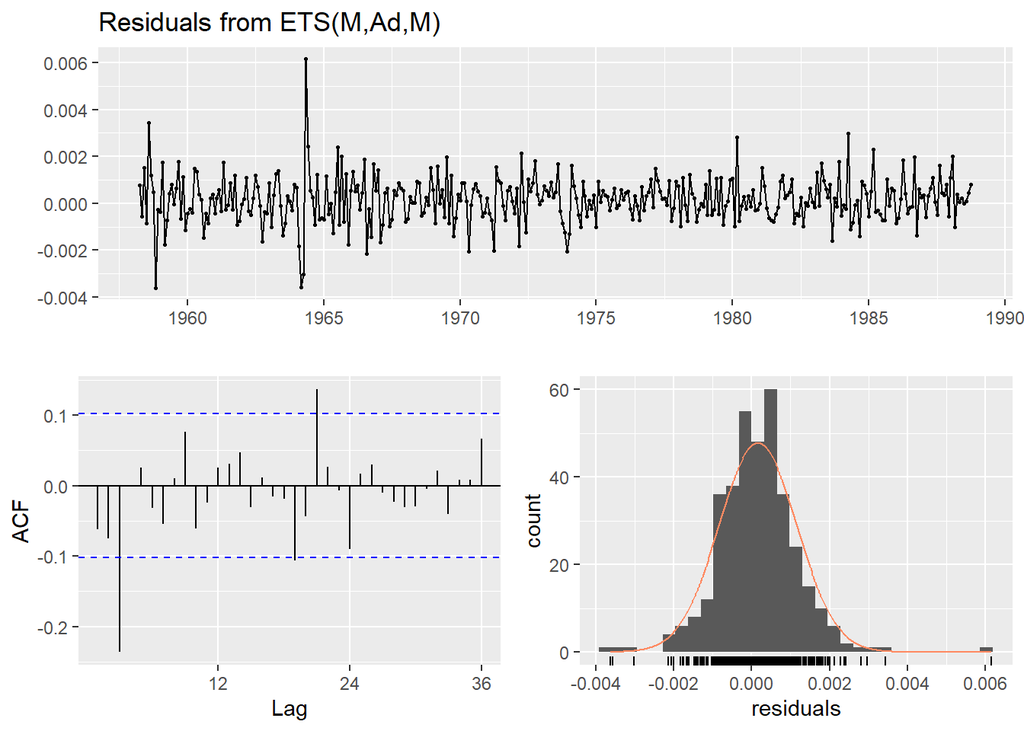

```
##
##  Ljung-Box test
##
## data:  Residuals from ETS(M,Ad,M)
## Q* = 48.079, df = 7, p-value = 3.437e-08
##
## Model df: 17.   Total lags used: 24
```

```r
checkresiduals(pred_Hawai)
```

# 5. Le modèle est-il fiable?

Comment pourrait-il être amélioré?

Il faudra comparer avec un modèle basé sur l’algorithme de holt-Winter’s. La tendance générale (hausière) et l’effet saisonnier seront pris en considération dans ce genre d’algorithme.